# act_report

## Report: act_report

### Insights:

Given below are the insights gained from analysing the wrangled datasets.

1. The most common dog breed according to this analysis was found to be Golden Retriever. It was confirmed that this does not imply that Golden Retriever has the commonest dog stage - Golden Retriever was found to be the most common dog breed in the dataset. A careless intuitive guess would be to attribute the commonest dog breed with the commonest dog stage. A review found this to be false. It is not enough, that Golden Retriever is the commonest dog breed, to imply that the commonest dog stage will apply to the Golden Retriever dog breed group. Curiosity led to wanting to know what the image of this commonest dog breed look like, with jpg_url provided and Python libraries, the image was viewed as below;
- **Golden Retriever**

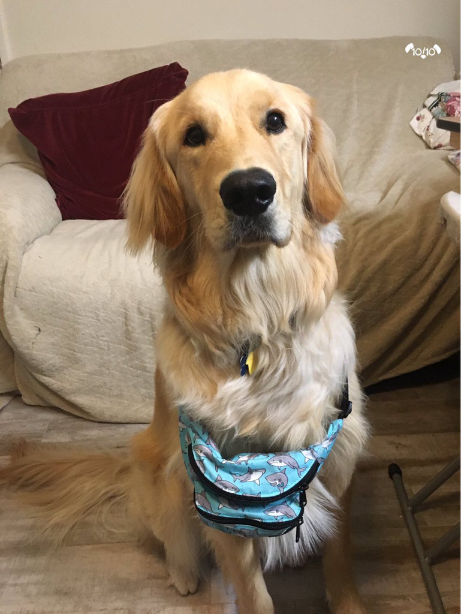

and the plot showing the 5 most common dog breeds is given below;

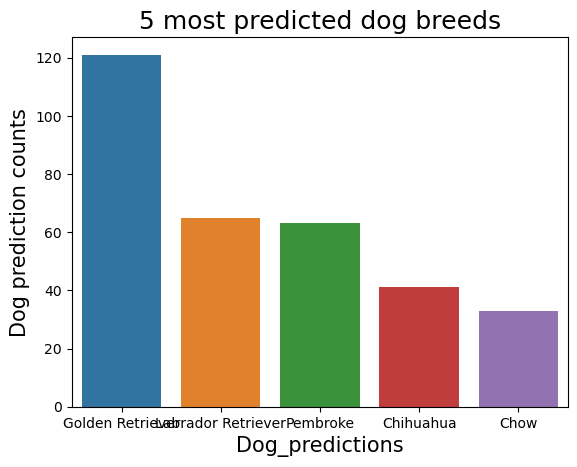

1. Ratings around 12 have the highest distribution. While the analysis was done to check how distributed the dog ratings were, it was found, from the data frame used, that the ratings with rating_numerators around 12 have the highest distribution. The visualization can be found below;

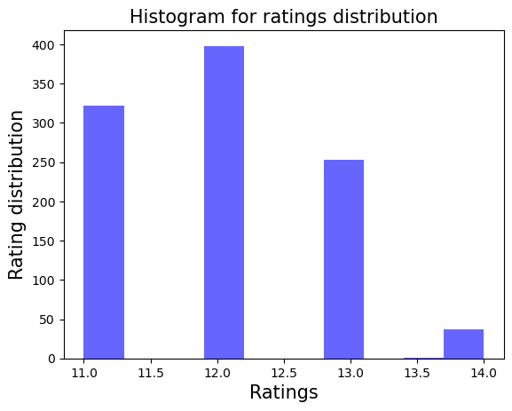

The histogram shows how distributed the rating scores were.

1. The most common dog stage was found to be pupper. This stage does not belong only to the commonest dog breed - Just as seen in the case of the most common dog breed, this pupper is the most common dog stage but it does not imply that it is the dog stage for the most common dog breed. A review was done to clarify this probable misconception. The image of first the dog with the most common dog stage (pupper) was viewed below;
- **Dog breed with pupper dod stage**

[figure not shown]

The plot showing the 5 most common dog stages is given below;

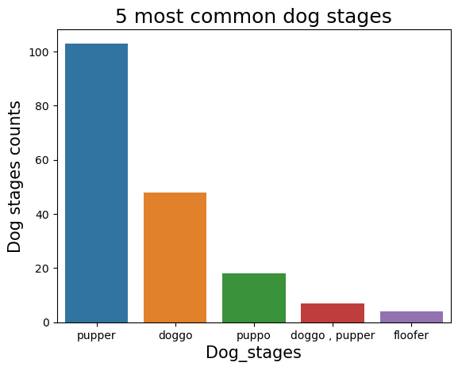

1. It was also found that the year with the highest aggregate of favorite ratings is 2017 - see the visualization below, showing the aggregated favorite ratings grouped by year.

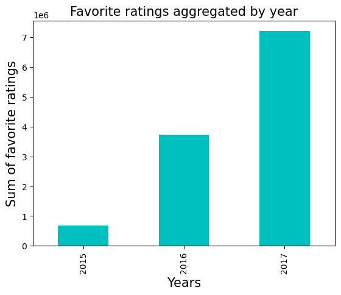

The aim of these analyses is not to show the best or worst dog breed. This is just for the sake of project assignments. Further research, examination, analysis, and documentation are recommended before drawing any conclusion.